# NCAA Men’s Tournament First Round Upsets

John Kane

2018-03-18

Unless you follow mid-major conferences closely, when it comes time to picking first round upsets in the NCAA Tournament you’re likely either picking teams at random, or going off the analysis of the “experts” on TV, the internet, or podcasts. I won’t address those who pick their upsets and Cinderella teams at random here, instead this post is about those who combine whatever they know about the field in a given year with what they see, read, and hear in the media. If you consume a lot this media you may be tempted to pick a lot of upsets, which by definition should be rare.

Although it is noisy, the NCAA Tournament Selection Committee provides some guidance to team strength by seeding each team 1-16. Thanks to a dataset from a [Kaggle competition](https://www.kaggle.com/c/march-machine-learning-mania-2017/data) that provides tournament results from 1985-2016, I’ve put together an analysis that aims to offer guidance on how many upsets you could expect in the first round, and from which matchups they come from. I define an upset to be anytime a numerically higher seeds beats a numerically lower seed (e.g. a 10 seed beats a 7 seed)

### Data Prep

#### Load Libraries and Data

```r
library(tidyverse)
library(magrittr)
library(knitr)
results <- read_csv(file = paste0(data_path,"TourneyCompactResults.csv"))
seeds <- read_csv(file = paste0(data_path,"TourneySeeds.csv"))
slots <- read_csv(file = paste0(data_path,"TourneySlots.csv"))
seasons <- read_csv(file = paste0(data_path,"Seasons.csv"))
colnames(results) <- tolower(colnames(results))
colnames(seeds) <- tolower(colnames(seeds))
colnames(slots) <- tolower(colnames(slots))
colnames(seasons) <- tolower(colnames(seasons))
```

#### Light data cleaning

```r
# convert colnames to lowercase
colnames(results) <- tolower(colnames(results))
colnames(seeds) <- tolower(colnames(seeds))
colnames(slots) <- tolower(colnames(slots))
colnames(seasons) <- tolower(colnames(seasons))

# parse the seed variable to get the region and numeric seed
seeds %<>%
  mutate(region = str_sub(seed,1,1),
         seed = as.numeric(str_sub(seed,2,3)))
```

#### Restructure the data

```r
results2 <-
  results %>%
  select(-daynum,-wscore,-lscore,-numot) %>%                                  # drop uneeded variables
  inner_join(.,                                                               # append winning team seeds and regions
             seeds %>% rename(wseed = seed,wregion = region),
             by = c("season","wteam" = "team")) %>%
  inner_join(.,                                                               # append losing team seeds and regions
             seeds %>% rename(lseed = seed,lregion = region),
             by = c("season","lteam" = "team")) %>%
  mutate(matchup = paste0(pmin(wseed,lseed),"-",pmax(wseed,lseed)),           # create new variables indicating the matchup
         upset =  ifelse(wseed > lseed, 1,ifelse(wseed == lseed, 0.5,0))) %>% # and if it was an upset
  select(season,matchup,upset,wregion,lregion)

head(results2)
```

```
## # A tibble: 6 x 5
##   season matchup upset wregion lregion
##    <int>   <chr> <dbl>   <chr>   <chr>
## 1   1985     8-9     1       X       X
## 2   1985    6-11     1       Z       Z
## 3   1985    1-16     0       W       W
## 4   1985     8-9     1       Y       Y
## 5   1985    3-14     0       Z       Z
## 6   1985    5-12     1       X       X
```

### Data Visualization

#### Number of upsets each year, by matchup

The first question I’m exploring in a data visualization is the number of upsets each season by matchup. There are 32 seasons worth of data in the results, so each chart will represent 32 seasons.

##### Aggreate number of matchups by season

```r
by_season <- results2 %>%
  filter(matchup %in% c('1-16','2-15','3-14','4-13','5-12','6-11','7-10','8-9'), wregion==lregion) %>%
  group_by(season,matchup) %>%
  summarize(upsets = sum(upset))
```

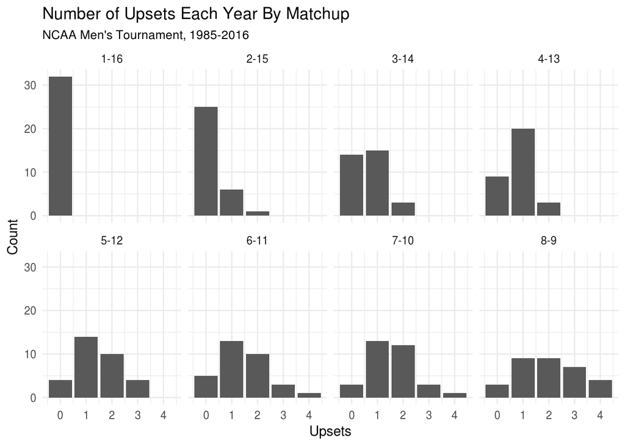

```r
ggplot(data = by_season,
       aes(x = upsets)) +
  facet_wrap(~matchup,ncol = 4) +
  geom_bar() +
  scale_x_continuous("Upsets") +
  scale_y_continuous("Count") +
  ggtitle("Number of Upsets Each Year By Matchup",sub = "NCAA Men's Tournament, 1985-2016") +
    theme_minimal()
```

Some oberservations from this chart: * The number of upsets increases as you move from the 1-16 to the 8-9 games. * The tournament committee seems to do a good job; there are fewer upsets of the stronger teams and the more evenly matched teams are the more likely there is to be an upset. * The most likely outcome every year is for there to be 0 upsets of 1 and 2 seeds, with at least one upset of each of teams seeded 3-7, with a tie of either 1 or 2 upsets of an 8 seed by a 9 seed. * There is more scatter in the number of upsets as you move from the 1-16 to the 8-9 games.

#### Trend in upsets over time, by matchup

The second question I want to address is whether there is any sort of trend in the number of upsets. Though not the topic of this post, it is of interest and could lead to good follow-up analysis. I’ve added a smooth line interpolation of each of the datapoints.

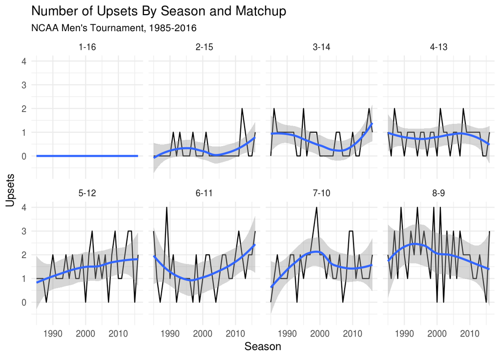

```r
ggplot(data = by_season,
       aes(x = season, y = upsets)) +
  facet_wrap(~matchup,ncol = 4) +
  geom_line() +
  geom_smooth(method = 'loess') +
  scale_x_continuous("Season") +
  scale_y_continuous("Upsets") +
  ggtitle("Number of Upsets By Season and Matchup",sub = "NCAA Men's Tournament, 1985-2016") +
    theme_minimal()
```

Some observations from this chart: * In the last few years there may be a trend for an increased likelihood of upsets in the 2-15 and 3-14 games. * A trend for an upset in 6-11 games appears to have begun back around the year 2000. * A trend for upsets in 5-12 games appears to have been a slow, ongoing phenomenon since the tournament began. * The line chart indicates that the closer two seeds are to each other, the nosier the outcome . * No glaring indication that upsets are any more likely in recent years than in the more distant past

### Single game upset probability

What is the chance of an upset in any one game? We can use the data to determine an empirical upset probability.

```r
upset_prob <-
results2 %>%
  filter(matchup %in% c('1-16','2-15','3-14','4-13','5-12','6-11','7-10','8-9'), wregion==lregion) %>%
  group_by(matchup) %>%
  summarise(upset_prob = sum(upset)/n())
```

```r
kable(upset_prob)
```

| matchup | upset_prob |
| --- | --- |
| 1-16 | 0.0000000 |
| 2-15 | 0.0625000 |
| 3-14 | 0.1640625 |
| 4-13 | 0.2031250 |
| 5-12 | 0.3593750 |
| 6-11 | 0.3593750 |
| 7-10 | 0.3906250 |
| 8-9 | 0.5000000 |

One way to use this information to pick your bracket would be for each game roll a weighted die through the `sample()` function in R to determine if there was an upset or not.

```r
set.seed(123)
p <- 0.39
sample(c(1,0),1,prob = c(p,1-p))
```

```
## [1] 0
```

Indicating you would not choose an upset for this game.

### Number of upsets in a given tournment

A second way to use the empirical upset probabilities would be to allow yourself a little discretion with who you choose to be upset. In the previous example you are the mercy of the die in each instance. You may end up picking a 3-14 upset, but not the one that seems most likely based on other datapoints (e.g. your own analysis, media takes) you receive.

So instead what you can do is roll the die for all four matchups in a given tournament and then, if there are any upsets, you can choose which ones you’d like to select.

For example, you can pick the number of upsets in the four 7-10 matchups this way:

```r
set.seed(123)
p <- 0.39
sample(c(1,0),4,prob = c(p,1-p), replace = TRUE)
```

```
## [1] 0 1 0 1
```

So in this case you would select, based on additional analysis, two ten seeds to win.

#### Still random

A valid critique of this approach is that you are still leaving a lot of things to chance, in the above example two upsets were selected, but the most likely outcome is actually for only one upset, albeit only slightly.

```r
c(dbinom(1,4,0.39),dbinom(2,4,0.39))
```

```
## [1] 0.3540904 0.3395785
```

#### Expectation vs. Reality

We can use these empirical upset probabilities to simulate how many upsets in a particular round we would expect to see, then compare that to what has actually happened in reality.

```r
expectation <-
do.call(rbind, lapply(upset_prob$upset_prob, function(x) 1 - pbinom(0:3,4,x))) %>%
  data.frame() %>%
  `colnames<-`(c("p1","p2","p3","p4"))
expectation$matchup <- c('1-16','2-15','3-14','4-13','5-12','6-11','7-10','8-9')
#expectation %>% select(5,1:4)
```

```r
reality <-
results2 %>%
  filter(matchup %in% c('1-16','2-15','3-14','4-13','5-12','6-11','7-10','8-9'), wregion==lregion) %>%
  group_by(season,matchup) %>%
  summarise(num_upsets = sum(upset)) %>%
  ungroup() %>%
  mutate(one_plus = ifelse(num_upsets >= 1,1,0),
         two_plus = ifelse(num_upsets >= 2,1,0),
         three_plus = ifelse(num_upsets >= 3,1,0),
         four = ifelse(num_upsets ==4,1,0)) %>%
  group_by(matchup) %>%
  summarise(prob_one_plus = sum(one_plus)/n(),
            prob_two_plus = sum(two_plus)/n(),
            prob_three_plus = sum(three_plus)/n(),
            prob_four = sum(four)/n())
```

In the below chart, negative values indicate that the scenarios have occurred more often than you would expect based on single-game upset probabilities.

```r
e_vs_r <-
expectation %>%
  inner_join(reality, by = "matchup") %>%
  select(1,2,6,3,7,4,8,5,9) %>%
  mutate(expectation_vs_reality1 = round(p1 - prob_one_plus,2),
         expectation_vs_reality2 = round(p2 - prob_two_plus,2),
         expectation_vs_reality3 = round(p3 - prob_three_plus,2),
         expectation_vs_reality4 = round(p4 - prob_four,2)) %>%
  select(8,10,11,12,13)
kable(e_vs_r)
```

| matchup | expectation_vs_reality1 | expectation_vs_reality2 | expectation_vs_reality3 | expectation_vs_reality4 |
| --- | --- | --- | --- | --- |
| 1-16 | 0.00 | 0.00 | 0.00 | 0.00 |
| 2-15 | 0.01 | -0.01 | 0.00 | 0.00 |
| 3-14 | -0.05 | 0.03 | 0.02 | 0.00 |
| 4-13 | -0.12 | 0.09 | 0.03 | 0.00 |
| 5-12 | -0.04 | 0.02 | 0.01 | 0.02 |
| 6-11 | -0.01 | 0.02 | 0.01 | -0.01 |
| 7-10 | -0.04 | 0.01 | 0.04 | -0.01 |
| 8-9 | 0.03 | 0.06 | -0.03 | -0.06 |

### Some Recommendations

If you agree with this approach you could use the following heuristic, that if there is a greater than 50% likelihood of a number of upsets, you should go with that.

So, in this case you would choose

No upsets in matchups for: * 1-16, 2-15 1 upset in : * 3-14, 4-13, 5-12, 6-11 2 Upsets in: * 7-10, 8-9

### Conclusion

I think this analysis demonstrates that the NCAA committee for the most part seeds appropriately. We are less likely to see upsets that involve lower numerically seeded teams. Upsets still do happen though.

In the course of doing this analysis I had some ideas for possible extensions: * Extend this analysis into the Round of 32 and beyond * compare chalk vs random brackets and points scored in traditional office-pool bracket scoring * extend analysis into a Bayesian one, using appropriate prior and conjugate distributions